# Process Notebook

Connie Xu, Arielle Herman, Zhirui (Ariel) Luo, Grace Li

3/18/2021

[output not shown]

## Introduction

As discussed in other sections of our repository, this project sought to explore a factors related to socioeconomic conditions, student debt, inequities, and policy. This was a realy broad topic so we did a decent amount of exploration of the data prior to deciding on a more specific topic.

## The Data

We first worked with the 2019 College Scorecard to look at some trends that we thought would be interesting. The following is the dataset and some basic columns added to it for our analysis work.

[output not shown]

```
 [1] "X1"              "UNITID"          "INSTNM"          "CITY"            "state"
 [6] "ZIP"             "lat"             "long"            "UGDS"            "ADM_RATE"
[11] "CONTROL"         "ACTCMMID"        "SAT_AVG"         "COSTT4_A"        "UNEMP_RATE"
[16] "DEBT_MDN"        "MN_EARN_WNE_P10" "MD_EARN_WNE_P10" "UGDS_WHITE"      "UGDS_BLACK"
[21] "UGDS_HISP"       "UGDS_ASIAN"      "UGDS_AIAN"       "UGDS_NHPI"       "School"
[26] "State"           "True"            "ADM_RATE_ALL_1"  "Year"            "Year_Starting"
[31] "Year_Ending"     "uni_rank"
```

### Selected Columns (Described in College Scorecard)

| variable | description |
| --- | --- |
| UNITID | IPEDS Unit ID |
| INSTNM | Institution Name |
| CITY | description |
| state | state |
| ZIP | Zip Code |
| DEBT_MDN | The median original amount of the loan principal upon entering repayment |
| UGDS | Number |
| ADM_RATE | Admission Rate |
| CONTROL | Private / Public Nonprofit (1 and 2) vs. For-Profit (3) Schools |
| MN_EARN_WNE_P10 | Min Earning after 10 Years (not used due to incomplete data) |
| MD_EARN_WNE_P10 | Med Earning after 10 Years (not used due to incomplete data) |
| UGDS_WHITE; UGDS_BLACK; UGDS_HISP; UGD.S_ASIAN | Proportion of Undergrads (White, Black, Hispanic, Asian) |
| UGDS | Number of Undergrads |
| School | Same as INSTNM (disregard - used to filter out community colleges) |
| ADM_RATE_ALL_1 | Admission Rate by OPE ID (not used in the end) |
| Year, Year_Starting, Year_Ending | Year Starting (twice due to how the data was read in) and Year Ending period covered by the scorecard |

### Additional Filtering / Column Mutation

```r
# Selectivity Categories were made guided by as-yet unpublished work from Conwell et al. (2022 exp.) [1] as well as by articles from the US News and Rankings
sc <- sc %>%
  dplyr::mutate(uni_rank = case_when(
    ADM_RATE < 0.05 ~ 'elite',
    ADM_RATE < 0.2 ~ 'highly selective',
    ADM_RATE < 0.3 ~ 'more selective',
    ADM_RATE < 0.5 ~ 'selective',
    ADM_RATE < 0.7 ~ 'less selective',
    TRUE ~ 'not selective')) %>% mutate(uni_rank = factor(uni_rank, levels=c('not selective', 'less selective', 'selective', 'more selective', 'highly selective', 'elite')))
```

## Preliminary (Very Rough) Drafts - Searching for Trends

As discussed in the introductory section, we had far too many subtopics within our dataset and we wanted to better explore a specific sub-topic. Thus, we began with trying to identify patterns within our dataset and other related datasets.

We started by testing whether or not we would be able to generate a graph of where universities in the US are located. This was mostly to validate that the lat and lon columns were working properly and were not going to cause issues if we were to plot these institutions on a map.

```r
#note
us <- map_data("state")
us_states <- as_data_frame(us) %>% dplyr::rename(state=region)
us_states
```

| long | lat | group | order | state | subregion |
| --- | --- | --- | --- | --- | --- |
| -87.46201 | 30.38968 | 1 | 1 | alabama | NA |
| -87.48493 | 30.37249 | 1 | 2 | alabama | NA |
| -87.52503 | 30.37249 | 1 | 3 | alabama | NA |
| -87.53076 | 30.33239 | 1 | 4 | alabama | NA |
| -87.57087 | 30.32665 | 1 | 5 | alabama | NA |
| -87.58806 | 30.32665 | 1 | 6 | alabama | NA |
| -87.59379 | 30.30947 | 1 | 7 | alabama | NA |
| -87.59379 | 30.28655 | 1 | 8 | alabama | NA |
| -87.67400 | 30.27509 | 1 | 9 | alabama | NA |
| -87.81152 | 30.25790 | 1 | 10 | alabama | NA |

[output cut: 990 more lines]

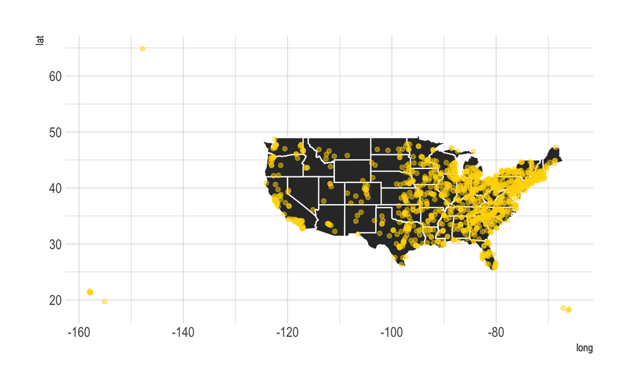

```r
mapping=aes(x = lat, y = long)
ggplot(us,  aes(x = long, y = lat, group=group)) +
  geom_polygon(aes(), color='white') +
  theme_ipsum() + theme(panel.grid = element_blank())+ geom_point(data = df, aes(x = long, y = lat, group=UNITID),color='gold',alpha=0.5)
```

We then started trying to look at some trends that could be compiled into our visualization project. Some themes we were interested in were *race*, *socioeconomic status*, *student debt*, and *economic outcomes*.

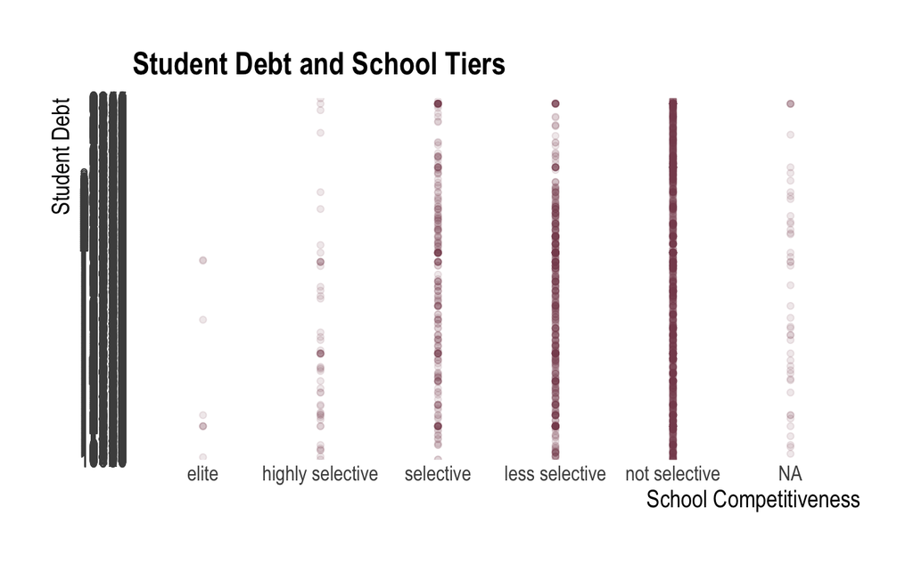

```r
sc_sub <- sc %>% subset(DEBT_MDN != 'PrivacySuppressed') %>% drop_na(uni_rank) %>% drop_na(DEBT_MDN)
sc_sub$uni_rank_cat = factor(sc_sub$uni_rank, levels=c('elite','highly selective','selective','less selective','not selective'))

ggplot(sc_sub, aes(x=uni_rank_cat,y=DEBT_MDN)) +
  geom_point(color = '#87495F',alpha=.12) +
  theme_ipsum(base_size = 12, axis_title_size = 14) +
  theme(
    panel.grid.major = element_blank(),
    panel.grid.minor = element_blank()) +
      ggtitle("Student Debt and School Tiers") +
  labs(fill = "Selectivity", y="Student Debt", x = "School Competitiveness")
```

The next thing we did was look the percentage of Black students vs. the Median Debt.

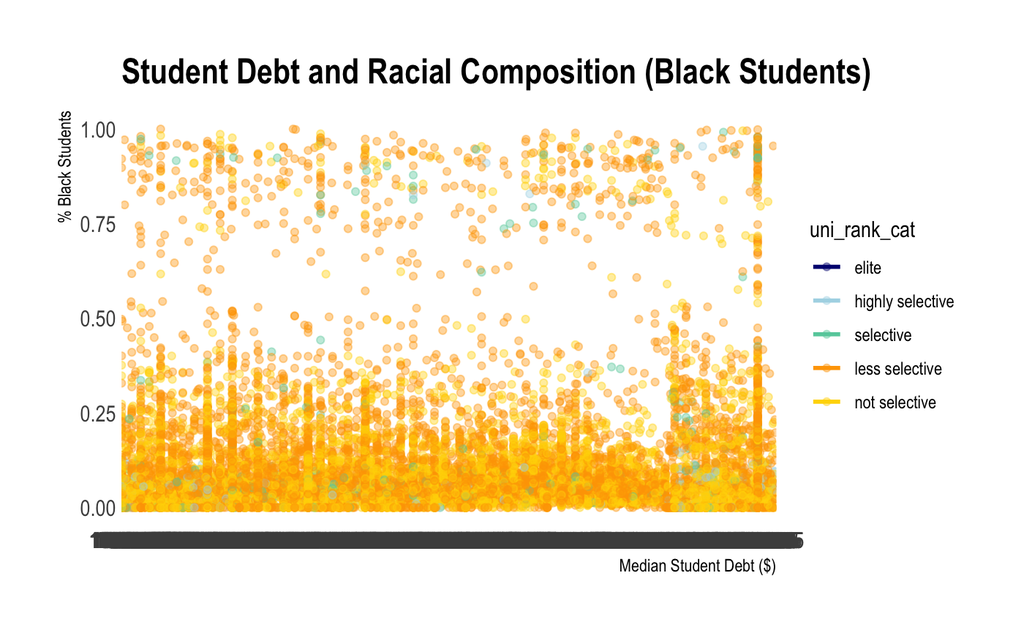

Again this is poorly presented (and as I recognized later, the major issue with all of the grey at the axis was due to an overcrowded axis label such that we would be unable to see what the x and y values included). This also did not include a very clear trend - as such, I left ‘race and student debt’ alone for the time being as we were attempting to work on scaling down to more specific topics.

[1] - Conwell, Jordan A. and Natasha Quadlin. Forthcoming. “Race, Gender,Higher Education, and Socioeconomic Attainment: Evidence from Baby Boomers at Mid-Life.” Social Forces. DOI: 10.1093/sf/soab010.